# Projet sur les données du mil

Promo 2016 Data Science

01/08/2016

## Organisation

Nous proposons d’organiser les travaux de TP selon [Noble (PLoS Computational Biology,2009)](http://dx.doi.org/10.1371/journal.pcbi.1000424). Cette même organisation est repectée pour le cours d’initiation au processus de Dirichlet.

```r
if(Sys.info()["user"] == "fontez"){
  project.dir <- "C:/Users/fontez/Documents/enseignement/DPcours"
  lib.dir <- "~/R/win-library/3.2"
}
stopifnot(file.exists(project.dir))
data.dir <- paste0(project.dir, "/data")
stopifnot(file.exists(data.dir))
src.dir <- paste0(project.dir, "/src")
stopifnot(file.exists(src.dir))
results.dir <- paste0(project.dir, "/results")
stopifnot(file.exists(results.dir))
doc.dir <- paste0(project.dir, "/doc")
stopifnot(file.exists(doc.dir))
task.dir <- paste0(doc.dir)
setwd(task.dir)
```

Cet enseignement sur 20h se compose d’une journée de cours-TP qui se poursuit par un projet à réaliser sous R sur deux après midi. Le projet se déroulera comme suit :

## Objectifs

- Biologique : Estimer la structure de populations à partir des données génétiques du mil
  - Estimer le nombre de populations
  - Affecter les individus dans les populations
- Statistique computationnelle : Proposer un modèle, un algorithme d’estimation
  - Modèle : adapter Onogi et al BMC Bioinformatics 2011
  - Estimation : écrire le Gibbs sampler
  - Analyser les sorties du Gibbs
  - Pour aller plus loin : comparer les résutats avec d’autres approches
- Informatique : paralélliser l’algorithme d’estimation et vérifier ses propriétés
  - Parallélisation
  - Vérification du gain de temps et de la distribution sur les coeurs

## Description des données

Les données (SNP) sont codées comme suit à chaque locus :

- Homozygote allèle alternatif est codé 0,
- Hétérozygote est codé 1
- Homozygote allèle de référence est codé 2
- Donnée manquante codée 9

L’allèle de référence est celui qui est le moins fréquent dans la population. On constate que ce codage donne directement le nombre de copie de l’allèle de référence à chaque locus pour chaque individu.

```r
# lecture des donnees de genetiques du Mil
setwd(data.dir)
data.mil <- read.fwf("GBSQ-MD-Mi_xLEA_maf4.geno",widths = rep(1,55), header = F)
View(data.mil)
```

- Description des données :
  - Nombre d’individus : 20777
  - Nombre de markers (SNP) : 55
  - Histogramme des fréquences alléliques

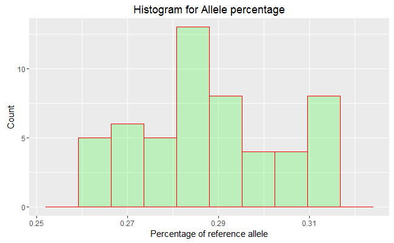

TP

- AFC sur le tableau disjonctif

## Script estimation DPM pour données génétiques - SNP (Onogi 2011)

TD

- Ecrire l’algorithme du MCMC (Gibbs sampler) à partir de l’article d’Onogi (2011) et de la fonction *genetic.crp*
- Compléter les fonctions *ajour.gamma* et *vrais.ij*

### Création des fonctions nécessaires

```r
#---------- fonctions de calculs intermÃ©diares -----------#

ajour.gamma <- function(){

}

vrais.ij <- function(){

}
```

```r
#----- fonction d'initialisation du Gibbs -----------#

initialisation <- function(mydata = data.mil , classes = NULL){

  # creation du vecteur classe d'assignation aux classes : Tous les individus dans la classe 1 pour commencer
  if (is.null(classes)) classes <- rep( 1 , nrow(mydata))

  # nombre d'indivus par classe
  nn <- as.numeric(table(factor(classes)))

  # Mise à jour des lois des clusters
  gamma <- list()
  for ( i in 1:max(classes) ) gamma[[i]] <- ajour.gamma(mydata[classes == i,])

  # valeurs en sortie de la fonction
  return(list(classes=classes, nn=nn, gamma=gamma))
}
```

```r
#--- Fonction simulation d'un CRP a posteriori ---#

genetic.crp <- function(mydata = data.mil , classes = classes , nn = nn, alpha = alpha, lambda = lambda, J, niter = niter) {

  classes.Gibbs <- NULL

  for( iter in 1:niter ){

    #-------------- Gibbs sampler---------------#

    for ( i in 1:nrow(mydata) ){

      # 1. remove i from classes

      nn[classes[i]] <- nn[classes[i]] - 1
      if (nn[classes[i]] == 0){

        # supprimer la classe vide
        gamma[[classes[i]]] <- NULL
        nn <- nn[-classes[i]]

        # renumÃ©roter les classes
        classes[classes > classes[i]] <- classes[classes > classes[i]] - 1

      } else {

        # Mise Ã  jour de la loi du cluster sans l'individu i
        gamma[[classes[i]]] <- ajour.gamma(mydata[classes == classes[[i]],])
      }

    # 2. existing proba

    num.proba <- NULL

    for ( j in 1:length(nn) ){
      num.proba <- c(num.proba, nn[j] * vrais.ij(gamma.j = gamma[[j]], donneei = mydata[i,], J = 2, lambda = lambda))
    }

    # 3. new proba

    num.proba <- c(num.proba, alpha * vrais.ij(gamma.j = gamma[[j]], donneei = mydata[i,], J = J, lambda = lambda))

    # 4. update

      classes[i] <- rmultinom(n = 1, size = 1, prob = proba)
      if (length(nn) < classes[i]) nn[classes[i]] <- 0
      nn[classes[i]] <- nn[classes[i]] + 1
      gamma[[classes[i]]] <- ajour.gamma(mydata[classes == classes[[i]],])
    }

  #
  classes.Gibbs <- rbind(classes.Gibbs,classes)
  }

# valeurs en sortie de la fonction
return(classes.Gibbs = classes.Gibbs, alpha = alpha, lambda = lambda)
}
```

```r
#-fonction de mise à jour des paramètres du DP : non implémenté-#
```

### Mise en oeuvre dpm

```r
# hyperparamètres
alpha <-
lambda <-
J <-

# paramètres du mcmc
niter <-

# programme final dpm

init <- initialisation()

result <- genetic.crp(classes = init$classes , nn = init$nn, alpha = alpha, lambda = lambda, J = J, niter = niter)
```

## Analyse des résultats

### Convergence chaîne mcmc

```r
# le nombre K de classes

# l'affectation du premier individu

# choix burnin

burnin <-
```

### Présentation et commentaire des résultats classification

```r
# calcul du maximum a posteriori (map)

simposterior <- result$classes.Gibbs[burnin:niter,]

# i = 1 simple

for ( i in 2:max(simposterior) ){
  sous_cas <- simposterior[apply(simposterior,2,"max") == i,]

  # renommer les classes en fonction de la taille (effectif) et en fonction de l'individus de plus bas rang
  # puis créer un vecteur des individus sortés dans l'ordre et dans l'ordre des classes (plus petit au plus grand)
  # puis table
  interm <- apply(simposterior,1,"sort")
  prev <- rep("C",6)
  for(a in 1:6) {
    for(b in 1:4) {
      prev[a] <- paste(prev[a],interm[b,a],sep="")
    }
  }
  table(prev)

  # garder sur i la classif la plus fréquente
}




# rajout de la colonne result$map à mydata

# mise en forme (dplyr) et visualisation (ggplot) de la classification
```

## Comparaison une autre approche de réduction de la dimension (optionnel)

```r
# Conchetta Burgetta et Muriel Tavaud
```

## Parallelisation

### Initiation à la parallelisation sous R

### Application à la fonction genetic.crp

```r
# répartition des données sur les clusters : uniform split

# Mise à jour de l'allocation aux super-clusters - label switching

# programme final avec parallelisation initialisation() et genetic.crp()

# detectCores()
# getDoParWorker()
# registerDoMC()
# foreach??
```

### Parallelisation du dpm (Onogi 2011) (optionnel)

## Intérêts-limites parallelisation

```r
# detectCores()
# getDoParWorker()
# registerDoMC()
# foreach??
# system.time()
```